# pmml文件转换及测试教程-V2.3

## 1.文件准备

- 1.以二进制文件保存的xgb模型

**本例中对应test_mdl.model**

- 2.fmap文件

**本例中对应test_mdl.fmap**

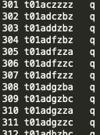

该文件具体生成方式如下：

```
field_name是入模的所有字段。

field_type有三种：

    q(默认)代表连续型变量；
    i代表分类变量；
    int代表整数型变量。

多数情况下 默认即可满足要求。
```

```python
def generate_fmap(field_name,model_name,path,field_type='q'):
    if field_name==[]:
        return('invalid input.')
    l = len(field_name)
    if type(field_type)==str:
        res = '\n'.join([str(i)+'\t'+field_name[i]+'\t'+field_type for i in range(l)])
    else:
        res = '\n'.join([str(i)+'\t'+field_name[i]+'\t'+field_type[i] for i in range(l)])
    with open(path+model_name+'.fmap','w') as f:
        f.write(res)
    print('your feature map saved at '+path+model_name+'.fmap')
```

- 3.测试数据集，格式为csv(需要带字段名，顺序无要求，不能带index，缺失填NA，应该包含fmap文件里的所有字段)

**本例中对应test_pmml_input.csv**

- 1. target_name(目标字段名)，字符串即可

**本例中规定为y**

## 2.模型转换成pmml

- 1.打开命令行/终端
- 2.输入cd c:\ReadMe\pmml_test
- 2.输入java -jar c:\soft\jpmml-xgboost\target\jpmml-xgboost-executable-1.3-SNAPSHOT.jar --model-input test_mdl.model --fmap-input test_mdl.fmap --target-name y --pmml-output test_mdl.pmml

## 3.pmml分数验证

- 1.打开命令行/终端
- 2.输入cd c:\ReadMe\pmml_test
- 3.输入java -cp c:\soft\jpmml-evaluator\pmml-evaluator-example\target\pmml-evaluator-example-executable-1.5-SNAPSHOT.jar org.jpmml.evaluator.EvaluationExample --model test_mdl.pmml --input test_pmml_input.csv --output test_pmml_output.csv

**注：在C:\ReadMe\pmml_test路径下还有一个result文件夹，存放的是2、3步骤的运行结果，如果用户想要把自己的模型转换成pmml测试，需要先将模型文件从服务器中导出，然后在桌面可采用类似的方式，注意文件路径要保持正确，最好使用绝对路径**